# cloud_c1044105

## PERFORMANCE EVALUATION OF TERAPIXEL RENDERING IN CLOUD (SUPER) COMPUTING

```
SUSHANTH SHIVPURA RAMESH - C1044105
Module :CSC8634
```

**Table of Content**

1. Abstract
2. Introduction
3. Business Understanding
4. Data Set Overview
5. Data Prepocessing
6. Data Analyses and Modelling
7. Results & Conclusion
8. Future Scope
9. Personal Reflection
10. References

## 1. Abstract

Cloud computing has allowed the businesses and researchers to scale up or scale down the computing resources as per the needs without requiring investing capital upfront for physical infrastructure. This has helped in leveraging the pay as you use model. By allocating and optimizing the cloud architecture resources we can further reduce the cost. The aim of the analysis is to extract information from the terapixel image generated data from the application and system metrics and pinpoint where the resource optimization should be focused. This project provides insight into key performance metrics around task assignments, GPU characteristics for terapixel rendering using numerical and exploratory data analysis.

## 2. Introduction

Cloud services, which offer wide a range of services such as Software as a Service (SaaS), Infrastructure as a Service (IaaS) and Platform as a Service (PaaS) that are delivered to customers over the internet. In recent times we can clearly see a shift in using these cloud services which are offered by Google cloud Platform, Amazon Web services etc. rather than setting up their own hardware infrastructure on their premise (on prem infrastructure). Using Cloud services offers some advantages than setting up a on perm infrastructure such as, renting or leasing extensive range of hardware infrastructure which saves huge capital which is requires to setup on prem. The other major advantage of using cloud service is that resources can be scaled up or scaled down based on the work load. This would help us to leverage the pay as you use model offered by the cloud services i.e., we are only billed based on the amount of time we use the resource for.

Image rendering is a GPU resource consuming task. Using Infrastructure or Platform as a service offered by cloud services would eliminate the hardware setup and initial investment cost constraints. An example use case and implementation for rendering images in real time using IaaS cloud infrastructure can be found in “Image-Based Network Rendering of Large Meshes for Cloud Computing” [1]. Terapixel 3D city visualization of Newcastle Upon Tyne uses a scalable IaaS cloud GPU node for the rendering. The Cloud services do not completely optimize the use of the underlying resources. To improve the scalability and optimizing the GPU resource utilization we are initiating the data mining project of the Terapixel rendering cloud architecture.[2] The project will focus on exploratory data analysis and follow CRISP-DM methodology.

## 3. Business Understanding

The cloud architecture on which the terapixel images are rendered uses compute nodes that heavily relies on the underlying GPU hardware. GPUs are power hungry hardware, as its main performance is established based on the number of parallel tasks it can run simultaneously. So, there are lot of factors that can affect the performance of the GPU.

The aim of this data mining and analysis project is to extract the performance evaluation metrics from the cloud architecture that is implemented to support the terapixel image rendering. Analysing this metrics would help us to identify how to improve the cost efficiency in running this cloud solution and optimizing the performance of rendering the image by tweaking the GPU utilization. we are using the following questions as an aid to analyse the data extracted from the cloud solution hardware.

- How is the GPU temperature and performance interrelated?
- Is there any relation between increased power drawn by the GPU and render time?
- Is there any particular GPU cads which perform better than the others ?
- Which event types dominates the task runtimes?
- Is there any specific pattern in the tiles or pixels which utilizes the GPU more or less to render?

```python
# mounting the drive to collab
from google.colab import drive
drive.mount('/content/drive')
```

```python
# importing modules and packages
import pandas as pd
import numpy as np
import matplotlib.pyplot as plt
import seaborn as sns
%matplotlib inline
from google.colab import files
import IPython
from scipy.sparse import coo_matrix
from datetime import datetime as dt, timedelta, date
from dateutil import parser
```

```python
# copying data from drive and unzipping
! cp /content/drive/MyDrive/TeraScope.zip -d /content/
!unzip -qq /content/TeraScope.zip
```

```python
# reading the csv files as dataframes . (copy the path of the 3 files as below )

gpu = pd.read_csv("/content/TeraScope/gpu.csv")
app_checpnt= pd.read_csv("/content/TeraScope/application-checkpoints.csv")
task = pd.read_csv("/content/TeraScope/task-x-y.csv")
```

## 4. Data Set Overview

There are three CSV files extracted from the application checkpoint and system metric output while rendering of terapixel image. The three data files consists of Application Checkpoint data, GPU data and Task-X-Y data. An initial data understanding of these data frames are as below.

**Application Checkpoints Data:** The data frame consists of 660400 rows and 6 columns as seen summary of the data frame. The column names of the data frame are interpreted as follows:

- **Timestamp:** Date and time of the event measured in milliseconds.
- **Hostname:** Auto-assigned name by azure batch system for each of the virtual machine. There are 1024 unique hostnames.
- **EventName:** There are 5 event that takes place while rendering the image
  > - **TotalRender:** Rendering the entire task
  > - **Saving Config:** Specific configurations related to each task are saved
  > - **Render:** Tiles of the image that is being rendere
  > - **Tiling:** Post-processing of the rendered tile
  > - **Uploading:** Output of the post-processed image tile are uploaded to azure storage
- **EvenType:** starting or terminating of an event , START or STOP state Jobid: There distinct states of the azure batch job which refers to the level of zoom while rendering the image (4,8,12).
- **Taskid:** Contains unique ids of the azure batch task. Each of the task id would have all the five event names associated along with the start and stop timestamp.

```python
print("Application_checkpoint Data contains: {0} Rows and {1} Columns".format(app_checpnt.shape[0], app_checpnt.shape[1]))
```

```
Application_checkpoint Data contains: 660400 Rows and 6 Columns
```

```python
# Application Checkpoint Data preview
#print("Application Checkpoint Data preview")
app_checpnt.head(5)
```

|  | timestamp | hostname | eventName | eventType | jobId | taskId |
| --- | --- | --- | --- | --- | --- | --- |
| 0 | 2018-11-08T07:41:55.921Z | 0d56a730076643d585f77e00d2d8521a00000N | Tiling | STOP | 1024-lvl12-7e026be3-5fd0-48ee-b7d1-abd61f747705 | b47f0263-ba1c-48a7-8d29-4bf021b72043 |
| 1 | 2018-11-08T07:42:29.842Z | 0d56a730076643d585f77e00d2d8521a00000N | Saving Config | START | 1024-lvl12-7e026be3-5fd0-48ee-b7d1-abd61f747705 | 20fb9fcf-a927-4a4b-a64c-70258b66b42d |
| 2 | 2018-11-08T07:42:29.845Z | 0d56a730076643d585f77e00d2d8521a00000N | Saving Config | STOP | 1024-lvl12-7e026be3-5fd0-48ee-b7d1-abd61f747705 | 20fb9fcf-a927-4a4b-a64c-70258b66b42d |
| 3 | 2018-11-08T07:42:29.845Z | 0d56a730076643d585f77e00d2d8521a00000N | Render | START | 1024-lvl12-7e026be3-5fd0-48ee-b7d1-abd61f747705 | 20fb9fcf-a927-4a4b-a64c-70258b66b42d |
| 4 | 2018-11-08T07:43:13.957Z | 0d56a730076643d585f77e00d2d8521a00000N | TotalRender | STOP | 1024-lvl12-7e026be3-5fd0-48ee-b7d1-abd61f747705 | 20fb9fcf-a927-4a4b-a64c-70258b66b42d |

- **gpuSerial:** Unique serial number associated with each of the 1024 GPU cards
- **gpuUUID:** Unique id generated by azure system to the GPU card
- **powerDrawWatt:** Power drawn by each GPu card in Watts.
- **gpuTemC:** Recording of temperature of the GPU card while operating in Celsius.
- **gpuUtilPerc:** Percantage of gpu processor cores utilized.
- **gpuMemUtilPerc:** Percentage of GPU RAM utilized.

```python
print("GPU Data contains: {0} Rows and {1} Columns".format(gpu.shape[0], gpu.shape[1]))
```

```
GPU Data contains: 1543681 Rows and 8 Columns
```

```python
# GPU Data preview
gpu.head(5)
```

|  | timestamp | hostname | gpuSerial | gpuUUID | powerDrawWatt | gpuTempC | gpuUtilPerc | gpuMemUtilPerc |
| --- | --- | --- | --- | --- | --- | --- | --- | --- |
| 0 | 2018-11-08T08:27:10.314Z | 8b6a0eebc87b4cb2b0539e81075191b900001C | 323217055910 | GPU-1d1602dc-f615-a7c7-ab53-fb4a7a479534 | 131.55 | 48 | 92 | 53 |
| 1 | 2018-11-08T08:27:10.192Z | d8241877cd994572b46c861e5d144c85000000 | 323617020295 | GPU-04a2dea7-f4f1-12d0-b94d-996446746e6f | 117.03 | 40 | 92 | 48 |
| 2 | 2018-11-08T08:27:10.842Z | db871cd77a544e13bc791a64a0c8ed50000006 | 323217056562 | GPU-f4597939-a0b4-e78a-2436-12dbab9a350f | 121.64 | 45 | 91 | 44 |
| 3 | 2018-11-08T08:27:10.424Z | b9a1fa7ae2f74eb68f25f607980f97d7000010 | 325217085931 | GPU-ad773c69-c386-a4be-b214-1ea4fc6045df | 50.23 | 38 | 90 | 43 |
| 4 | 2018-11-08T08:27:10.937Z | db871cd77a544e13bc791a64a0c8ed50000003 | 323217056464 | GPU-2d4eed64-4ca8-f12c-24bc-28f036493ea2 | 141.82 | 41 | 90 | 47 |

- **X :** x coordinates of the rendered image tile
- **Y :** y coordinates of the rendered image tile.
- **Level :** Zoom levels of image ranging from 1 to 12 while seeing only intermediate levels 4,8 and 12 derived while tiling process.

```python
print("task-x-y data contains: {0} Rows and {1} Columns".format(task.shape[0], task.shape[1]))
```

```
task-x-y data contains: 65793 Rows and 5 Columns
```

```python
#task-x-y data preview
task.head(5)
```

|  | taskId | jobId | x | y | level |
| --- | --- | --- | --- | --- | --- |
| 0 | 00004e77-304c-4fbd-88a1-1346ef947567 | 1024-lvl12-7e026be3-5fd0-48ee-b7d1-abd61f747705 | 116 | 178 | 12 |
| 1 | 0002afb5-d05e-4da9-bd53-7b6dc19ea6d4 | 1024-lvl12-7e026be3-5fd0-48ee-b7d1-abd61f747705 | 142 | 190 | 12 |
| 2 | 0003c380-4db9-49fb-8e1c-6f8ae466ad85 | 1024-lvl12-7e026be3-5fd0-48ee-b7d1-abd61f747705 | 142 | 86 | 12 |
| 3 | 000993b6-fc88-489d-a4ca-0a44fd800bd3 | 1024-lvl12-7e026be3-5fd0-48ee-b7d1-abd61f747705 | 235 | 11 | 12 |
| 4 | 000b158b-0ba3-4dca-bf5b-1b3bd5c28207 | 1024-lvl12-7e026be3-5fd0-48ee-b7d1-abd61f747705 | 171 | 53 | 12 |

## 5. Data Prepocessing

All the three datasets must be wrangled and merged before any analysis can be done. The following steps have been implemented as a part of data pre-processing.

First, we merge task-x-y.csv and application checkpoint.csv on job id and task id using left join. Next, we combine gpu.csv with the combined data frame of task-x-y.csv and application checkpoint.csv on time stamp. To ensure there are no duplicate data points, we remove duplicate rows from the merged data set.

The time stamps column on the data set cannot be directly used, we extract only the time part i.e. Hour:Minute:Second convert it to numeric from character and store it in a new column on the merged data set.

There are 5 events recorded namely TotalRender, Render, Tiling, saving config and uploading. Each of these events have a START and stop time. We have calculated the cumulative time duration of each of the event as follows.

10 data frames for the combination of 5 events and 2 event types has been created. Next, we merge the respective events on the task ids. With the merged data we calculate the time taken for each event using start and stop column. The duration is calculated by subtracting the start time from the stop time. Finally, we stack all the data frames and create a csv file for our analysis.

**Consideration's**

To analyse the tasks and event task that are run on GPU, we need to merge the GPU data with Application checkpoint data. The merge can be done based on the timestamp column and hostname. However, merging on time stamp directly would cause mismatching results. For the purpose of this analysis, we have done so, as we take the average values for most of the features this has a negligible errors on our results.

```python
# mering the data frames

# merging aoolication check point with task
df_app_task_mrg=pd.merge(app_checpnt,task,on=['taskId', 'jobId'], how='left')
# merging the pervioius data frame to gpu
df_atg_mrg = pd.merge(df_app_task_mrg, gpu, on=['timestamp'])
#----------------------------------------
# merging gpu data to the prviosuly merged dataframe
#renaming hostname_x , deleting hostname_y and removing duplicate rows
del df_atg_mrg['hostname_x']
df_atg_mrg = df_atg_mrg.rename(columns={'hostname_y': 'hostname'})
df_atg_mrg = df_atg_mrg.loc[:,~df_atg_mrg.columns.duplicated()]
# extracting time stamp and coverting from char to digits
df_atg_mrg["time"] = df_atg_mrg["timestamp"].apply(lambda x: parser.isoparse(x))
df_atg_mrg['time'] = pd.Series([dt.time(d) for d in df_atg_mrg['time']])
grp = df_atg_mrg.groupby(['eventName','eventType']).groups


# storing the index of start and stop of different event types such as tiling rendering..

rn_srt_ind = np.array(np.array(grp[('Render', 'START')]))
rn_stp_ind = np.array(np.array(grp[('Render', 'STOP')]))
svc_srt_ind = np.array(np.array(grp[('Saving Config', 'START')]))
svc_stp_ind = np.array(np.array(grp[('Saving Config', 'STOP')]))
ti_srt_ind = np.array(np.array(grp[('Tiling', 'START')]))
ti_stp_ind = np.array(np.array(grp[('Tiling', 'STOP')]))
tr_srt_ind = np.array(np.array(grp[('TotalRender', 'START')]))
tr_stp_ind = np.array(np.array(grp[('TotalRender', 'STOP')]))
up_srt_ind= np.array(np.array(grp[('Uploading', 'START')]))
up_stp_ind = np.array(np.array(grp[('Uploading', 'STOP')]))


# storing rows based on index calculated for each event
rn_strt = df_atg_mrg.iloc[rn_srt_ind]
rn_stp = df_atg_mrg.iloc[rn_stp_ind]
svc_strt = df_atg_mrg.iloc[svc_srt_ind]
svc_stp = df_atg_mrg.iloc[svc_stp_ind]
ti_strt = df_atg_mrg.iloc[ti_srt_ind]
ti_stp = df_atg_mrg.iloc[ti_stp_ind]
tr_strt = df_atg_mrg.iloc[tr_srt_ind]
tr_stp = df_atg_mrg.iloc[tr_stp_ind]
up_strt = df_atg_mrg.iloc[up_srt_ind]
up_stp = df_atg_mrg.iloc[up_stp_ind]

# joining respective events on task ids
df_render = pd.merge(rn_strt, rn_stp, on='taskId')
df_save_conf = pd.merge(svc_strt, svc_stp, on='taskId')
df_tiling = pd.merge(ti_strt, ti_stp, on='taskId')
df_TotalRender = pd.merge(tr_strt, tr_stp, on='taskId')
df_Uploading = pd.merge(up_strt, up_stp, on='taskId')

# dropping dupliate colnms
col_name =  ['x_x', 'y_x', 'level_x', 'gpuSerial_x', 'timestamp_x','timestamp_y', 'jobId_y', 'eventName_y', 'eventType_y', 'eventType_x', 'hostname_y',  'gpuUUID_x', 'powerDrawWatt_x', 'gpuTempC_x', 'gpuUtilPerc_x', 'gpuMemUtilPerc_x']

df_render = df_render.drop(columns= col_name)
df_save_conf = df_save_conf.drop(columns= col_name)
df_tiling = df_tiling.drop(columns= col_name)
df_TotalRender = df_TotalRender.drop(columns= col_name)
df_Uploading = df_Uploading.drop(columns= col_name)

#Renaming coulmns
col_new = ['eventName', 'jobId', 'taskId', 'hostname', 'START', 'x', 'y', 'level', 'gpuSerial', 'gpuUUID', 'powerDrawWatt', 'gpuTempC', 'gpuUtilPerc', 'gpuMemUtilPerc', 'STOP']

df_render.columns = col_new
df_save_conf.columns = col_new
df_tiling.columns = col_new
df_TotalRender.columns =col_new
df_Uploading.columns = col_new

# calculating the time take for each event using start and stop column
df_render["duration"] = df_render.apply(lambda x: abs(dt.combine(date.today(), x['START']) - dt.combine(date.today(), x['STOP'])), axis=1)
df_save_conf["duration"] = df_save_conf.apply(lambda x: abs(dt.combine(date.today(), x['START']) - dt.combine(date.today(), x['STOP'])), axis=1)
df_tiling["duration"] = df_tiling.apply(lambda x: abs(dt.combine(date.today(), x['START']) - dt.combine(date.today(), x['STOP'])), axis=1)
df_TotalRender["duration"] = df_TotalRender.apply(lambda x: abs(dt.combine(date.today(), x['START']) - dt.combine(date.today(), x['STOP'])), axis=1)
df_Uploading["duration"] = df_Uploading.apply(lambda x: abs(dt.combine(date.today(), x['START']) - dt.combine(date.today(), x['STOP'])), axis=1)



# creating a df with all the event data frames combined
df_event_comb = pd.concat([df_render, df_save_conf,df_tiling, df_TotalRender, df_Uploading  ])
df_event_comb['duration'] = (df_event_comb['duration'].dt.total_seconds())

# merging application check point and task file and calculating the time duration

#conveting timestamp into datetimeformat
df_app_task_mrg[['timestamp']]=df_app_task_mrg[['timestamp']].apply(pd.to_datetime,format='%Y-%m-%d %H:%M:%S.%f')

pd.options.mode.chained_assignment = None
#storing start and stop time in seperate column

start_df = df_app_task_mrg[df_app_task_mrg['eventType'] == 'START']
stop_df=df_app_task_mrg[df_app_task_mrg['eventType']=='STOP']

#Renaming the timestamp of start and stop as start_time and stop_time
start_df.rename(index=str, columns={"timestamp": "start_time"}, inplace = True)
stop_df.rename(index=str, columns={"timestamp": "stop_time"}, inplace = True)

#droping the eventType
stop_df.drop('eventType', axis = 1, inplace = True)
start_df.drop('eventType', axis = 1, inplace = True)

#merging the start_df and stop_df
str_stp_df=pd.merge(stop_df,start_df,on=['eventName','jobId','taskId','hostname','x','y','level'])
str_stp_df=str_stp_df.reindex(columns=['start_time']+str_stp_df.columns[:-1].tolist())

# adding the seperate time differnce column
str_stp_df["Duration"]=str_stp_df["stop_time"]-str_stp_df["start_time"]
#converting time difference into seconds
str_stp_df["Duration"]=(str_stp_df["Duration"]/np.timedelta64(1,'s')).abs()

# creating scv files for both the above data frames

df_event_comb.to_csv("/content/TeraScope/comb_data.csv")

str_stp_df.to_csv("/content/TeraScope/app_tsk_dur.csv")
```

## 6. Data Analyses and Modelling

With the data now merged and wrangled, we can now extract the necessary information for the questions men-tioned in the previous sections. To get a broad overview of the data and extract some interesting features of the data we would begin our initial analysis.

### Initial Analysis

```python
print(" First few rows of the merged data frame")
df_event_comb.head(5)
```

```
 First few rows of the merged data frame
```

|  | eventName | jobId | taskId | hostname | START | x | y | level | gpuSerial | gpuUUID | powerDrawWatt | gpuTempC | gpuUtilPerc | gpuMemUtilPerc | STOP | duration |
| --- | --- | --- | --- | --- | --- | --- | --- | --- | --- | --- | --- | --- | --- | --- | --- | --- |
| 0 | Render | 1024-lvl12-7e026be3-5fd0-48ee-b7d1-abd61f747705 | e7776af5-510d-4ec4-b2d3-222b5df3307b | dcc19f48bb3445a28338db3a8f002e9c00000I | 08:14:53.364000 | 36 | 180 | 12 | 323617042673 | GPU-cb998f1a-0b0d-cced-76a0-05dd129ff2ee | 26.70 | 36 | 0 | 0 | 08:15:32.380000 | 39.016 |
| 1 | Render | 1024-lvl12-7e026be3-5fd0-48ee-b7d1-abd61f747705 | 339d3724-dcf6-41f1-b30d-c71107befcee | db871cd77a544e13bc791a64a0c8ed5000001B | 08:21:58.845000 | 21 | 105 | 12 | 325117172104 | GPU-8caee719-8623-0ccf-d70c-dc5d934a2093 | 150.64 | 46 | 87 | 44 | 08:22:38.257000 | 39.412 |
| 2 | Render | 1024-lvl12-7e026be3-5fd0-48ee-b7d1-abd61f747705 | 1bf9597f-77bd-4b37-aadd-a5af9baa2308 | d8241877cd994572b46c861e5d144c85000006 | 07:53:10.809000 | 59 | 243 | 12 | 323617042670 | GPU-dad1d262-8319-b91e-e97e-686b7655f5dc | 89.39 | 47 | 89 | 40 | 07:53:50.814000 | 40.005 |
| 3 | Render | 1024-lvl12-7e026be3-5fd0-48ee-b7d1-abd61f747705 | 1bf9597f-77bd-4b37-aadd-a5af9baa2308 | d8241877cd994572b46c861e5d144c85000006 | 07:53:10.809000 | 59 | 243 | 12 | 323617021127 | GPU-045092d0-5454-f3a1-0fc8-05b5b0aa6832 | 150.11 | 40 | 88 | 60 | 07:53:50.814000 | 40.005 |
| 4 | Render | 1024-lvl12-7e026be3-5fd0-48ee-b7d1-abd61f747705 | e742280f-948b-4f6c-b663-bb7f40c41af2 | 6139a35676de44d6b61ec247f0ed865700000Z | 07:41:31.839000 | 173 | 5 | 12 | 325017018451 | GPU-5c551c80-c1ba-1af7-163c-862acd78af02 | 105.03 | 38 | 92 | 55 | 07:42:08.091000 | 36.252 |

```python
avg_data = df_event_comb[df_event_comb['eventName'] != 'TotalRender'][['gpuSerial', 'eventName', 'gpuTempC', 'gpuUtilPerc', 'gpuMemUtilPerc', 'powerDrawWatt', 'duration']].groupby(['gpuSerial','eventName']).mean()
avg_data.index.names = ['gpuSerial', 'eventName']
avg_data.reset_index(inplace=True)
```

```python
avg_data.head()
```

|  | gpuSerial | eventName | gpuTempC | gpuUtilPerc | gpuMemUtilPerc | powerDrawWatt | duration |
| --- | --- | --- | --- | --- | --- | --- | --- |
| 0 | 320118118607 | Render | 36.916667 | 88.583333 | 48.750000 | 105.404167 | 39.366583 |
| 1 | 320118118607 | Saving Config | 36.518519 | 70.185185 | 38.333333 | 84.607037 | 0.002704 |
| 2 | 320118118607 | Tiling | 36.440000 | 83.040000 | 44.880000 | 103.791600 | 0.937080 |
| 3 | 320118118607 | Uploading | 35.428571 | 31.785714 | 18.571429 | 62.997857 | 1.050143 |
| 4 | 320118118641 | Render | 39.375000 | 80.500000 | 44.312500 | 100.221250 | 42.524313 |

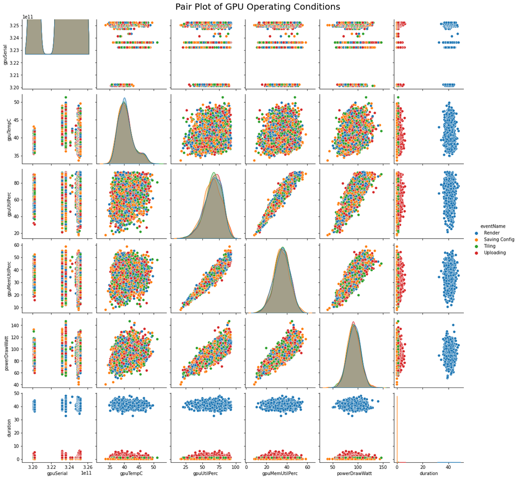

```python
f = sns.pairplot(avg_data, hue="eventName")
#sns.set(font_scale = 2) # settng text font scale...
f.fig.suptitle(" Pair Plot of GPU Operating Conditions", fontsize = 20, y=1.01)
plt.show()
```

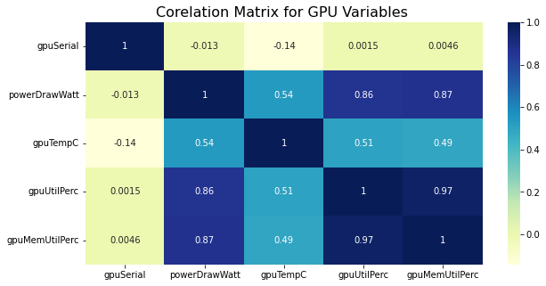

```python
plt.figure(figsize = (10, 5))
plt.title("Corelation Matrix for GPU Variables ", fontsize = 16)
sns.heatmap(gpu.corr(),annot=True, cmap="YlGnBu")
#sns.set(font_scale = 1)
plt.show()
```

From the above information we would be able to analyise the questions in the biusness objective.

### Events Dominating the Run Time

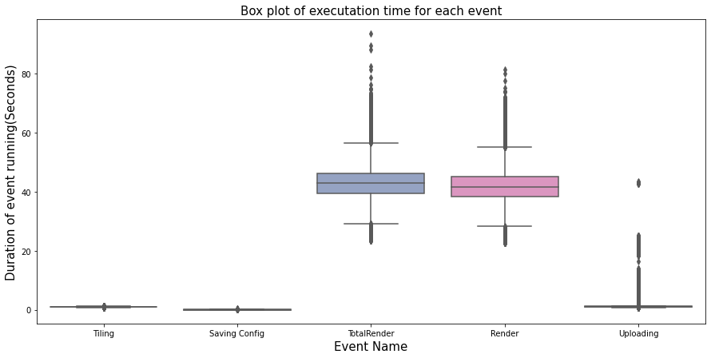

```python
# Box plot for Events to analyse which event is taking most of the computation time...
fig, ax = plt.subplots(figsize=(15, 7)) # Figure size...
sns.boxplot(x="eventName", y="Duration", data=str_stp_df, palette="Set2")
sns.set(font_scale = 1.5) # Text font scale...
plt.xlabel('Event Name', fontsize = 15)
plt.ylabel('Duration of event running(Seconds)', fontsize = 15)
plt.title("Box plot of executation time for each event", fontsize = 15)
plt.show()
```

From our intial analysis we already know that there are 3 unique Azure jobs ids present in the application-checkpoint dataset.We will try to analysise which of the event types dominate the task run time in these Azure jobs.

```python
print("UNIQUE AZURE JOBID's")
print(str_stp_df['jobId'].unique())
```

```
UNIQUE AZURE JOBID's
['1024-lvl12-7e026be3-5fd0-48ee-b7d1-abd61f747705'
 '1024-lvl8-5ad819e1-fbf2-42e0-8f16-a3baca825a63'
 '1024-lvl4-90b0c947-dcfc-4eea-a1ee-efe843b698df']
```

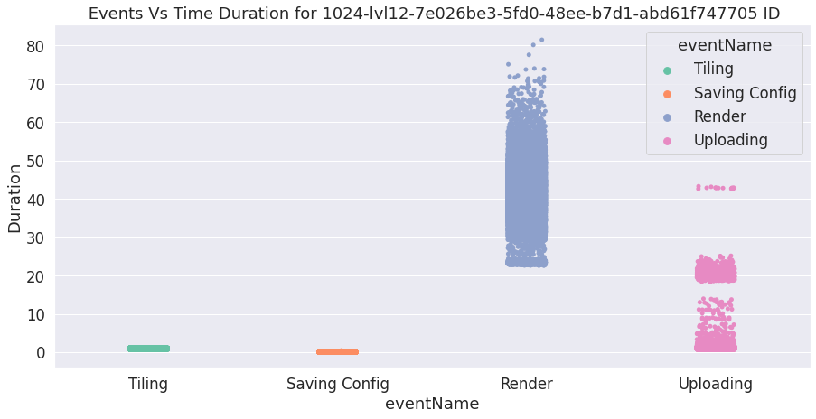

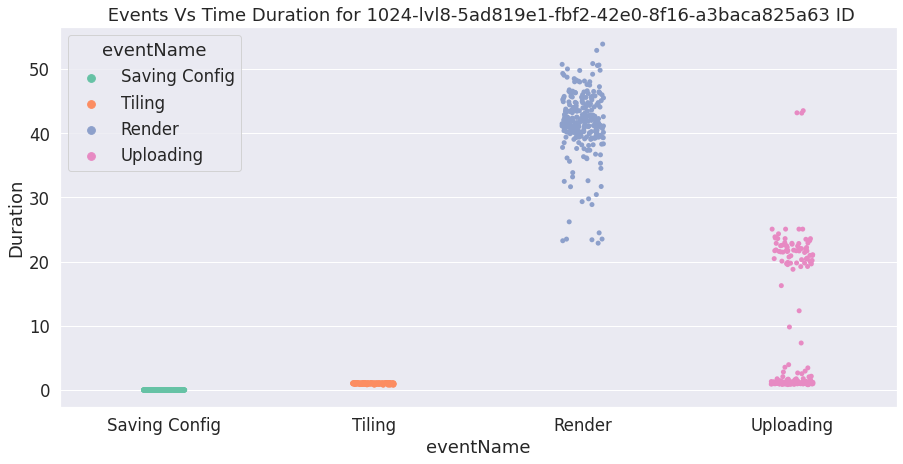

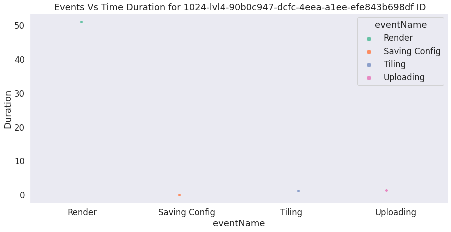

```python
azur_id=str_stp_df['jobId'].unique()
for i in azur_id:
  jobdf=str_stp_df[str_stp_df['jobId']==i]
  plt.figure(figsize=(15,7))
  fig=sns.stripplot(x='eventName',y='Duration',hue="eventName",data=jobdf[-(jobdf.eventName=='TotalRender')], palette="Set2").set_title( f" Events Vs Time Duration for {i} ID")
```

From all of the above plots for each of the unique Azure ids, we can further conclude that rendering event consumes more time than any other even followed by uploading event.

### GPU Parameters Analysis

```python
gpu_df=gpu[['powerDrawWatt','gpuTempC','gpuUtilPerc','gpuMemUtilPerc']]
```

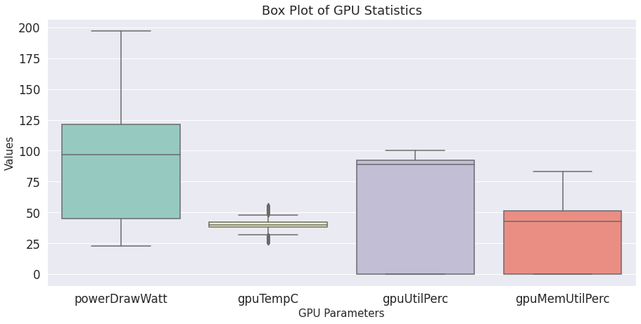

```python
plt.figure(figsize=(15,7))
sns.boxplot(x="variable", y="value", data=pd.melt(gpu_df), palette="Set3")
plt.title("Box Plot of GPU Statistics")
sns.set(font_scale = 1.5) # Text font scale...
plt.xlabel('GPU Parameters', fontsize = 15)
plt.ylabel('Values', fontsize = 15)
plt.show()
```

```python
print("Numerical Analysis of GPU Parameters")
gpu_df.describe()
```

```
Numerical Analysis of GPU Parameters
```

|  | powerDrawWatt | gpuTempC | gpuUtilPerc | gpuMemUtilPerc |
| --- | --- | --- | --- | --- |
| count | 1.543681e+06 | 1.543681e+06 | 1.543681e+06 | 1.543681e+06 |
| mean | 8.919838e+01 | 4.007560e+01 | 6.305820e+01 | 3.341359e+01 |
| std | 3.975742e+01 | 3.800243e+00 | 4.144816e+01 | 2.300107e+01 |
| min | 2.255000e+01 | 2.600000e+01 | 0.000000e+00 | 0.000000e+00 |
| 25% | 4.499000e+01 | 3.800000e+01 | 0.000000e+00 | 0.000000e+00 |
| 50% | 9.659000e+01 | 4.000000e+01 | 8.900000e+01 | 4.300000e+01 |
| 75% | 1.213400e+02 | 4.200000e+01 | 9.200000e+01 | 5.100000e+01 |
| max | 1.970100e+02 | 5.500000e+01 | 1.000000e+02 | 8.300000e+01 |

### Inter Play between GPU Performance and Temperature

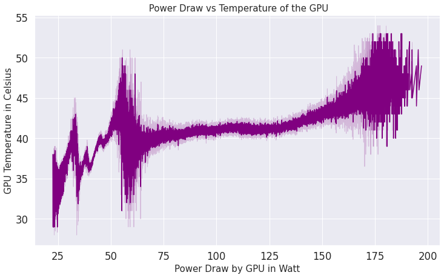

```python
# Line plot to show relation between power draw (performance) and GPU temperature...
fig, ax = plt.subplots(figsize=(12, 7)) # Figure size...
ax = sns.lineplot(data=gpu, x="powerDrawWatt", y="gpuTempC",color='purple')
sns.set(font_scale = 1.5)
plt.xlabel('Power Draw by GPU in Watt', fontsize = 15)
plt.ylabel('GPU Temperature in Celsius', fontsize = 15)
plt.title(" Power Draw vs Temperature of the GPU", fontsize = 15)
plt.show()
```

From the above plot we can perceive the following:

- There is an increase in GPU temperature with the increase in the GPU temperature as well.
- At around 60 Watt there is a spike in the temperature, so there may be some low performing GPUs where the temperature is increased even though the power drawn is less.
- There is no confirmation that as the temperature increases there is significant increase in performance or power drawn. Further analysis on GPU utilization and memory utilization would be required

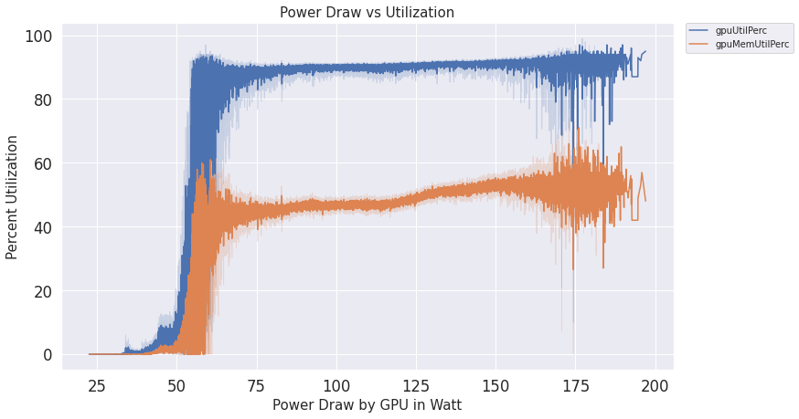

```python
# Line plot to see the relation between Power draw and gpu utilization and gpu memory utilization
fig, ax = plt.subplots(figsize=(12, 7))
ax = sns.lineplot(data=pd.melt(gpu[["powerDrawWatt", "gpuUtilPerc", "gpuMemUtilPerc"]], 'powerDrawWatt'), x="powerDrawWatt", y="value", hue = "variable", color ="RdYlBu")
plt.xlabel('Power Draw by GPU in Watt', fontsize = 15)
plt.ylabel('Percent Utilization', fontsize = 15)
plt.title("Power Draw vs Utilization", fontsize = 15)
plt.legend(bbox_to_anchor=(1.02, 1), loc='upper left', borderaxespad=0, fontsize = 10)
plt.show()
```

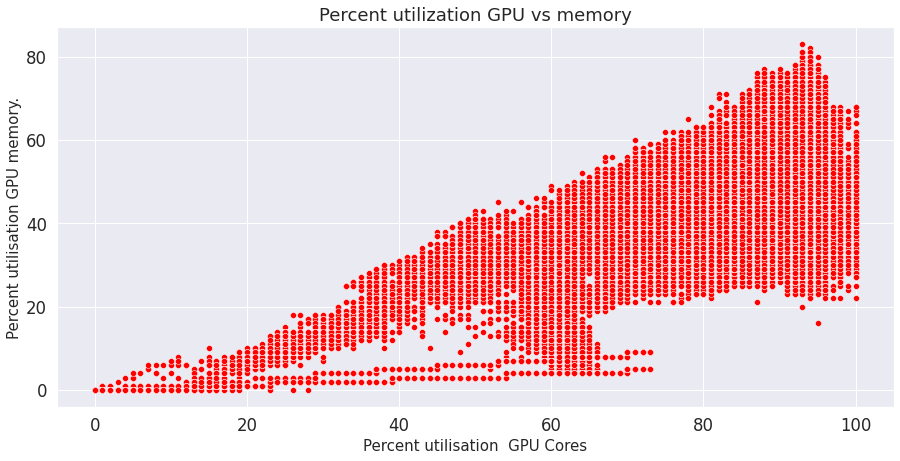

```python
# scatter plot for memory vs GPU
plt.figure(figsize=(15,7))
sns.scatterplot(x='gpuUtilPerc',y='gpuMemUtilPerc',data=gpu, color = 'Red')
plt.title("Percent utilization GPU vs memory")
plt.xlabel("Percent utilisation  GPU Cores",  fontsize = 15)
plt.ylabel("Percent utilisation GPU memory.",  fontsize = 15)
plt.show()
```

From the above plots we find that:

- There is an increase in both GPU utilization and GPU Memory as the power drawn by the GPU increases which is as expected because the GPU components utilization increases as the performance increases in turn the power consumption also increases. So, we can deduce that increase in power drawn by the GPU increases the performance
- Performance increase of the GPU after 60w is very marginal. As the power drawn is more there is a fluctuation in GPU utilization and memory utilization which confirms that the GPU is throttled. This can be because of some of the weaker GPUs or may be because of temperature or clock speed throttling.
- we can clearly see that the utilization of the memory linearly increases with GPU core utilization percent increases .so the GPU cores and memory utilization is highly corelated which is as expected .
- All the above conclusions made can also be verified from the pair plot as well.

### Corelation between Render Time and Power Drawn

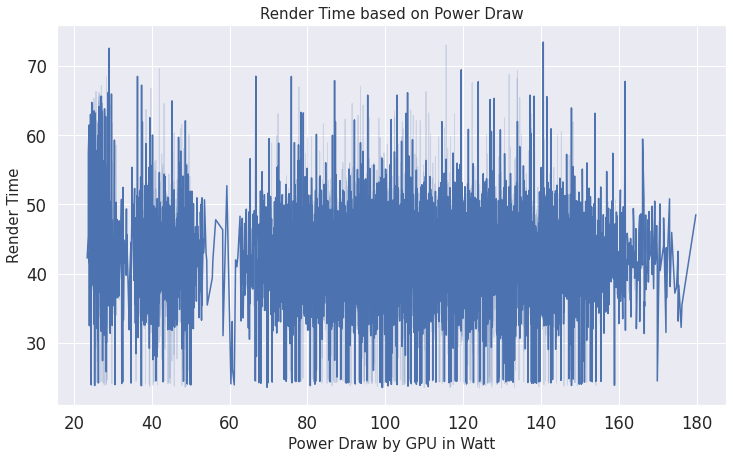

```python
# line plot of render time against power draw...
fig, ax = plt.subplots(figsize=(12, 7)) # Figure size...
ax = sns.lineplot(data=df_event_comb.query("eventName == 'TotalRender'"), x="powerDrawWatt", y="duration")
plt.xlabel('Power Draw by GPU in Watt', fontsize = 15)
plt.ylabel('Render Time', fontsize = 15)
plt.title("Render Time based on Power Draw", fontsize = 15)
plt.show()
```

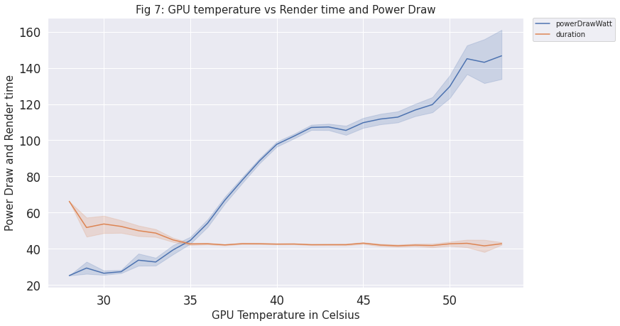

```python
# Line plot to see the relation between GPU temperature, Power draw (Performance) and Render time...
fig, ax = plt.subplots(figsize=(12, 7)) # Figure size...
ax = sns.lineplot(data=pd.melt(df_event_comb.query("eventName == 'TotalRender'")[["powerDrawWatt", "gpuTempC", "duration"]], 'gpuTempC'), x="gpuTempC", y="value", hue = "variable")
plt.xlabel('GPU Temperature in Celsius', fontsize = 15)
plt.ylabel('Power Draw and Render time', fontsize = 15)
plt.title("Fig 7: GPU temperature vs Render time and Power Draw", fontsize = 15)
plt.legend(bbox_to_anchor=(1.02, 1), loc='upper left', borderaxespad=0, fontsize = 10)
plt.show()
```

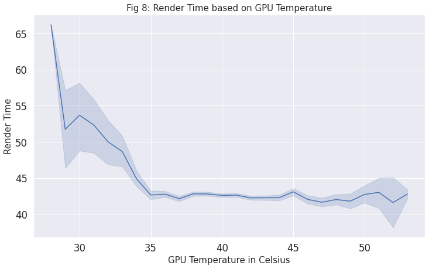

```python
# Line plot to see the variation in render time when GPU temperature increases...
fig, ax = plt.subplots(figsize=(12, 7)) # Figure size...
ax = sns.lineplot(data=df_event_comb.query("eventName == 'TotalRender'"), x="gpuTempC", y="duration")
plt.xlabel('GPU Temperature in Celsius', fontsize = 15)
plt.ylabel('Render Time', fontsize = 15)
plt.title("Fig 8: Render Time based on GPU Temperature", fontsize = 15)
plt.show()
```

From the above plots we can conclude the following:

- There is no improvement in render time as the power drawn by the GPUs increases.
- As temperature increases, we see that power drawn is increased and render time is decreased hence, we can say increase in temperature does not affect the performance much.
- Render time is decreasing drastically when temperature is approaching 35 degrees Celsius and is consistent thereafter.
- Overall, the power draw by the GPU doesn’t have any corelation with the render time.

### Computation Requirements for Different Tiles

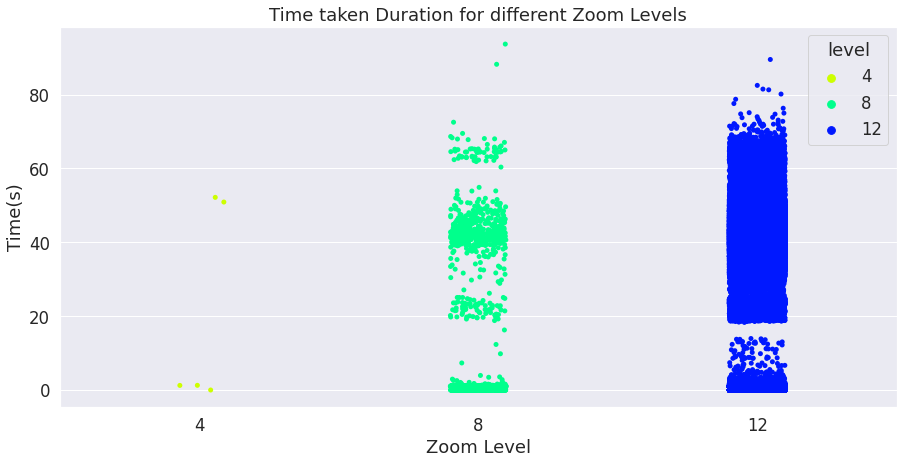

```python
#plot for zoom level type vs Time
plt.figure(figsize=(15,7))
plt.title("Time taken Duration for different Zoom Levels")
fig=sns.stripplot(x='level',y='Duration',hue="level",data=str_stp_df, palette ="gist_rainbow")
fig.set(xlabel="Zoom Level",ylabel="Time(s)")
plt.show()
```

```python
lev_4_df = str_stp_df.loc[str_stp_df['level'] == 4]
lev_8_df = str_stp_df.loc[str_stp_df['level'] == 8]
lev_12_df = str_stp_df.loc[str_stp_df['level'] == 12]
```

```python
print("Numerical summary of Zoom Level 4")
lev_4_df.describe()
```

```
Numerical summary of Zoom Level 4
```

|  | x | y | level | Duration |
| --- | --- | --- | --- | --- |
| count | 5.0 | 5.0 | 5.0 | 5.000000 |
| mean | 0.0 | 0.0 | 4.0 | 21.122000 |
| std | 0.0 | 0.0 | 0.0 | 27.782006 |
| min | 0.0 | 0.0 | 4.0 | 0.002000 |
| 25% | 0.0 | 0.0 | 4.0 | 1.246000 |
| 50% | 0.0 | 0.0 | 4.0 | 1.269000 |
| 75% | 0.0 | 0.0 | 4.0 | 50.911000 |
| max | 0.0 | 0.0 | 4.0 | 52.182000 |

```python
print("Numerical summary of Zoom Level 8")
lev_8_df.describe()
```

```
Numerical summary of Zoom Level 8
```

|  | x | y | level | Duration |
| --- | --- | --- | --- | --- |
| count | 1310.000000 | 1310.000000 | 1310.0 | 1310.000000 |
| mean | 7.454198 | 7.534351 | 8.0 | 19.632202 |
| std | 4.598863 | 4.653457 | 0.0 | 22.159412 |
| min | 0.000000 | 0.000000 | 8.0 | 0.002000 |
| 25% | 3.000000 | 3.000000 | 8.0 | 0.949000 |
| 50% | 7.500000 | 7.500000 | 8.0 | 1.130000 |
| 75% | 11.000000 | 12.000000 | 8.0 | 42.058250 |
| max | 15.000000 | 15.000000 | 8.0 | 93.697000 |

```python
print("Numerical summary of Zoom Level 12")
lev_12_df.describe()
```

```
Numerical summary of Zoom Level 12
```

|  | x | y | level | Duration |
| --- | --- | --- | --- | --- |
| count | 331355.000000 | 331355.000000 | 331355.0 | 331355.000000 |
| mean | 127.471141 | 127.474355 | 12.0 | 17.234791 |
| std | 73.896956 | 73.896938 | 0.0 | 20.575444 |
| min | 0.000000 | 0.000000 | 12.0 | 0.002000 |
| 25% | 64.000000 | 63.000000 | 12.0 | 0.902000 |
| 50% | 127.000000 | 128.000000 | 12.0 | 1.066000 |
| 75% | 191.000000 | 191.000000 | 12.0 | 40.742000 |
| max | 255.000000 | 255.000000 | 12.0 | 89.525000 |

```python
# Dropping duplicate data based on x and y values...
heatmap_data = df_event_comb.drop_duplicates(
  subset = ['x', 'y'],
  keep = 'last').reset_index(drop = True)

# Selecting rows with zoom lvl 12 and columns x, y, duration, and powerDrawWatt...
heatmap_data = heatmap_data[heatmap_data['level'] == 12][['x', 'y', 'powerDrawWatt', 'duration']]

# Converting long data(tabular format) to wide data(matrix format) which is suitable for heatmap...
heatmap_data = coo_matrix((heatmap_data.duration,(heatmap_data.x,heatmap_data.y)))
heatmap_data = heatmap_data.toarray()
```

[figure not shown]

```python
# heat map of newcastle upon tyne
fig, ax = plt.subplots(figsize=(18, 9)) # Figure size...
fig.suptitle(' Heatmap of Newcastle Upon Tyne', fontsize=20)
colormap = sns.color_palette("rocket", as_cmap=True)
rows, cols = 1, 2 # figure has 1 row and 2 columns...
plt.subplot(rows, cols, 1)
p = sns.heatmap(heatmap_data, cmap = colormap)
plt.subplot(rows, cols, 2)
img = plt.imread('/content/drive/MyDrive/map.png')
plt.imshow(img)
plt.show()
```

### Performance of GPUs based on their serial number.

```python
# Coverting gpuSerial to string from int...
gpu['gpuSerial'] = gpu['gpuSerial'].astype(str)
gpu_powerdraw = gpu[['gpuSerial', 'powerDrawWatt']].groupby(['gpuSerial']).mean()
gpu_powerdraw.index.names = ['gpuSerial']
gpu_powerdraw.reset_index(inplace=True)
gpu_powerdraw = gpu_powerdraw.sort_values(by = 'powerDrawWatt') # Sorting by powerDrawWatt...
print("Low Performing GPUs")
gpu_powerdraw.head()
```

```
Low Performing GPUs
```

|  | gpuSerial | powerDrawWatt |
| --- | --- | --- |
| 867 | 325117171574 | 80.510313 |
| 679 | 325017017790 | 80.742673 |
| 704 | 325017018552 | 81.087075 |
| 800 | 325017049295 | 81.226755 |
| 619 | 324917052619 | 81.242179 |

```python
print("High Performing GPUs")
gpu_powerdraw.tail()
```

```
High Performing GPUs
```

|  | gpuSerial | powerDrawWatt |
| --- | --- | --- |
| 100 | 323217056123 | 98.698678 |
| 794 | 325017049041 | 99.057575 |
| 130 | 323217056368 | 101.549633 |
| 405 | 323617021202 | 101.974324 |
| 491 | 323617042596 | 106.247462 |

From the above two tables we can see the high and low performing GPUs based on their serial numbers. There is no specific pattern of their performance based on serial numbers. On an average GPU with serial number **323617042596** tends to perform better than the rest.

## 7. Results & Conclusion

Overall, the project was moderately successful with scope for further analysis and improvements.

## 8. Future Scope

Possible extension of this project is a scalability planning that could use the information gain from this project as a consideration. Future implications on the work of this area are that with the rapid growth of the current cloud technology, would be able to build and implement machine learning models to allocate GPU resources based on the need of the computational power required.

## 9. Personal Reflection

Undertaking this project has increased my familiarity of using CRISP-DM helped me in streamlining the whole data mining process. Throughout the project, the most difficult process to be executed perfectly is the data wrangling process in which we need to redo the wrangling process until an appropriate data frame is produced. This project was built using jupyter notebook and I have used libraries such as Pandas, Matplotlib and Seaborn for exploratory data analysis and visualization which helped me learn data analysis techniques and im-prove my python coding skills. I have also explored new modules such as nbconvert in jupyter notebook to work with mark down document which helped me reducing my effort in report writing. Overall, I have enjoyed working on this project overcoming various hurdles along the way which was an experience for future projects.

## 10. References

[1] Okamoto, Y., Oishi, T. & Ikeuchi, K. Image-Based Network Rendering of Large Meshes for Cloud Computing. Int J Comput Vis 94, 12–22 (2011). https://doi.org/10.1007/s11263-010-0383-1

[2] Profes-sor Nick Holliman, Manu Antony, Stephen Dowsland, Professor Philip James, Mark Turner, "Petascale Cloud Supercomputing for Terapixel Visualization of a Digital Twin" in arXiv, Online Publication 2019.

[3] Visualizing Urban IoT Using Cloud Supercomputing by Nicolas Holliman, Manu Antony, Stephen Dowsland & Mark Turner